# Calculation and interpretation of physiological indices derived from tree ring d13C

##### COURSE: DISC, LTRR, UNIVERSITY OF ARIZONA. INSTRUCTORS: S. BELMECHERI & P. SZEJNER

### Instructions

The following code and comments should further your experience using tree ring and atmospheric d13C data to calculate WUE and other physiological indices. This exercise relies upon raw tree-ring d13C measurements, atmospheric d13C measurements and uses the photosynthesis biochemical model of Farqhuar 1982.

There are a few questions throughout to catalyze understanding and critical thinking. The analysis is broken into four main parts (including 20 questions). At the end, you should have gone through many of the steps commonly used for reconstructing and interpreting iWUE derived from tree ring d13C. You will also be familiar with uncertainties related to such calculations and best practices to perform them.

You will need to download the R project from https://github.com/SBelmecheri/DISCO-Ntebook3.git and set your own working directory. Once you open the Notebook 3.Rproj in R studio you can open the Notebook3.Rmd file to proceed with the exercise.

The 13C Time serie analyzed here is the same as Norebook 1. For this site the 13C was measured on alpha cellulose.

## PART 0: Setting up directories and files

You will need the three following files in one directory:

1. Tree-ring d13C measurements. The filename is `"LIL.txt"`
2. Atmospheric 13C and [CO2] data. The filename is`"ATM.txt"`
3. Regional temperature data. The filename is `"CRU_TT.txt"`

You will also need to install `rpmodel` packages:

```r
library(rpmodel)
```

You should see the above file names (and anything else in this directory) when you type (or copy and paste) the following line:

```r
list.files()
```

```
[1] "ATM.txt"              "CRU_PP.txt"           "CRU_TT.txt"           "DISCO-Ntebook3.Rproj"
[5] "LIL.txt"              "Notebook3.R"          "RNotebook3.log"       "RNotebook3.nb.html"
[9] "RNotebook3.Rmd"
```

If you see these files listed, you’re ready to roll!

## PART 1: Importing and plotting raw tree-ring isotope data [d13C] & Atmospheric Data

Import and plot the raw tree ring d13C dataset from `LIL.txt`:

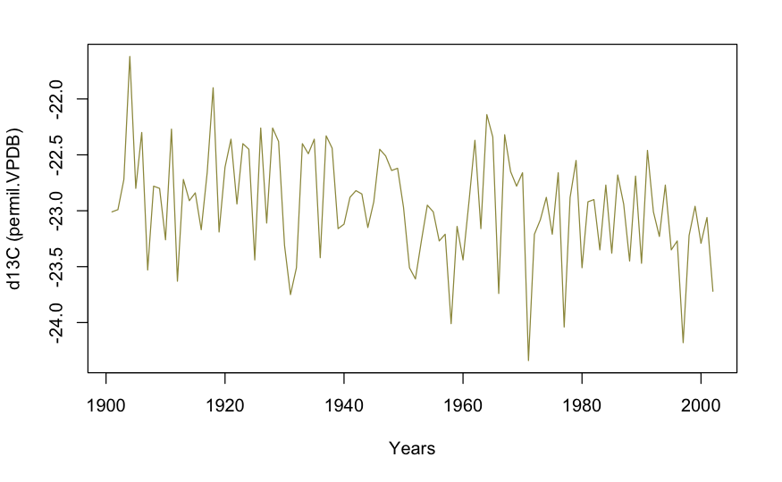

```r
TR13 <- ts((read.table("LIL.txt", header=T)), start=1901, frequency=1)
ts.plot(TR13,ylab="d13C (permil.VPDB)",xlab="Years", col="#9C964A")
```

Import and subset atmospheric data from `ATM.txt`:

```r
ATM <- ts((read.table("ATM.txt", header=T)), start=1901, frequency=1)
# subset d13C
ATM.13C <- ATM[,"atm13C"]
# subset CO2
ATM.CO2 <- ATM[,"atmCO2"]
```

Plot the atmospheric data (`ATM.13C` and `ATM.CO2`) dataset:

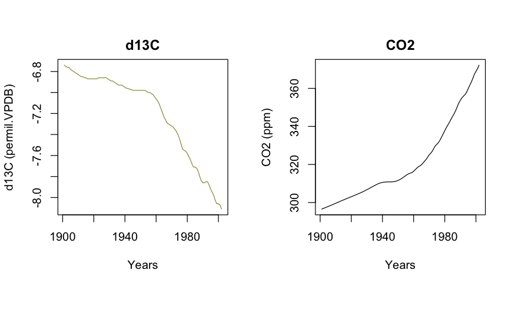

```r
layout(matrix(1:2,nrow = 1, ncol = 2,byrow = T), widths = c(3,3),heights = c(3,3),respect = TRUE)
ts.plot(ATM.13C,ylab="d13C (permil.VPDB)",xlab="Years", col="#9C964A",main="d13C")
ts.plot(ATM.CO2,ylab="CO2 (ppm)",xlab="Years", main="CO2")
```

Question 1: Compare both trends. Describe and interpret the relationship between the decline in d13C and the increase in CO2 concentration.

## PART 2: Calculating iWUE- SIMPLE APPROACH

The Farquhar, O’Leary, and Berry 1982 biochemical model describes the isotopic discrimination against 13C (Δ13C) during carbon diffusion and fixation by plants. The Farquhar et al. equation can be written as follows:

Δ13C = a+(b-a)*(ci/ca) EQ1

where:

a=4.4‰ is the fractionation due to CO2 diffusion in air through the stomata.

b= 28‰ is the apparent net fractionation by RuBisCO during carboxylation.

ci and ca are are the leaf intercellular and ambient partial pressure of CO2 (Pa), respectively.

From the equation above EQ1, ci can be calculated as follows:

ci = ca*(Δ13C-a)/(b-a) EQ2

We know `ca` from measurements. `ca` is in ppm. You can use `ca` in ppm as follows:

```r
# We know ca from measurements.ca is in ppm. you use use it as is
ca <- ATM.CO2 # in ppm
```

Or use `ca` in Pa as follows:

```r
# you need  r package "rpmodel"
library("rpmodel")
```

and the function `patm__lil {rpmodel}` to calculate atmospheric pressure at sea level as function of elevation (site elevation).

```r
elv= 1600 # Elevation above sea-level (m.a.s.l.)
patm_lil <- patm(elv, patm0 = 101325)
```

calculate `ca` as follows:

```r
ca <- ( 1.e-6 ) * ca * patm_lil  # in Pa
```

convert `ca` to a time series:

```r
ca <- ts(ca, start=1901, frequency=1)
```

Δ13C (`d13C.disc`) can then be calculated as follows:

```r
d13C.disc <- (ATM.13C-TR13)/(1+TR13/1000)
```

And `ci` as follows:

```r
a=4.4
b=28
ci <-  ca*(d13C.disc-a)/(b-a)
```

And the intrinsic water use efficiency`iwue` as follows:

```r
iwue <- (ca-ci)/1.6
```

plot the physiological indices:

```r
layout(matrix(1:6,nrow = 3, ncol = 2,byrow = F), widths = c(4,4),heights = c(2,2,2),respect = TRUE)
par(mar=c(4,5,2,0.1))
ts.plot(TR13,ylab="d13C (permill.VPDB)",xlab="Years", main="OBSERVATIONS")
ts.plot(d13C.disc,ylab="D13C (permill.VPDB)",xlab="Years", main="")
```

```r
ts.plot(ca,ylab="CO2 (pa)",xlab="Years", main="")
ts.plot(ci,ylab="ci (pa)",xlab="Years", main="FARQUHAR-MODEL")
```

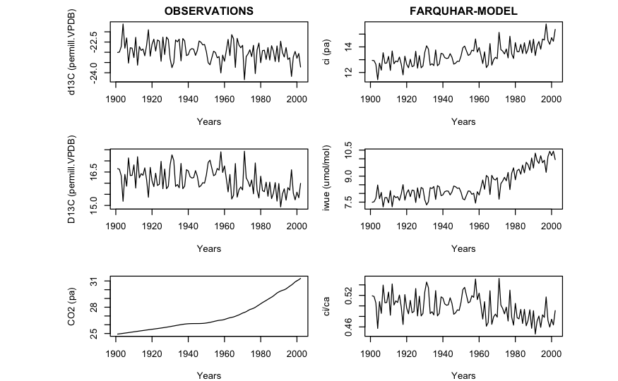

```r
ts.plot(iwue,ylab=" iwue (umol/mol)",xlab="Years", main="")
ts.plot(ci/ca,ylab="ci/ca",xlab="Years", main="")
```

Question 2: Describe the trends of the various physiological indices.

Question 3: Based on what you have learned in the Isotope theory lectures, describe the tree’s physiological response over time at this site.

## PART 3: Calculating iWUE- COMPREHENSIVE APPROACH

### Scaling from Stem to leaf

In the Farquhar et al. model, the d13C is the isotopic ratio for sugars fixed in the leaf. For tree-ring cellulose, a correction factor accounts for the offset of d13C between leaf sugars and tree-ring cellulose. The offset results from post-photosynthetic fractionation processes (Gessler et al., 2014).

Upscaling d13C measurements from tree rings to the leaf level can significantly improve estimates of Δ13C and reduce uncertainties (offsets) in determining the ratio of ci to ca.

We can scale tree ring d13 to leaf level using a factor `d`.

`d` represents the sum of post-photosynthetic isotope fractionations between the organic leaf matter and the plant material considered. Choose the d value based on the studied material (for this site, it is cellulose)

```r
# WARNING** Choose the appropriate d factor for this site**
# You can do this by discarding the d factor that does not correspond to the material analyzed at this site.
d=1.9 # for d13C measured in wood
d=2.1 # for d13C measured in cellulose
```

This correction can be made as follows:

```r
d13C.disc.leaf <- (ATM.13C-(TR13-d))/(1+(TR13-d)/1000)
```

Leaf level ci `ci.leaf` can be calculated as follows:

```r
ci.leaf <-  ca*(d13C.disc.leaf-a)/(b-a)
```

Leaf level intrinsic water use efficiency `iwue.leaf` can be calculated as follows:

```r
iwue.leaf <- (ca-ci.leaf)/1.6
```

now add the leaf level physiological indices to the previous plot:

```r
layout(matrix(1:6,nrow = 3, ncol = 2,byrow = F), widths = c(4,4),heights = c(2,2,2),respect = TRUE)
par(mar=c(4,5,2,0.1))
# Note you might need to adjust the ylim values.

plot(TR13,ylab="d13C (permill.VPDB)",xlab="Years", main="OBSERVATIONS")
plot(d13C.disc,ylab="D13C (permill.VPDB)",xlab="Years", main="", ylim=c(range(c(d13C.disc.leaf,d13C.disc))))
```

```r
        lines(d13C.disc.leaf, col="#0B775E", )
plot(ca,ylab="CO2 (ppm)",xlab="Years", main="")
```

```r
plot(ci,ylab="ci (pa)",xlab="Years", main="FARQUHAR-MODEL",ylim=c(range(c(ci, ci.leaf))))
        lines(ci.leaf, col="#0B775E")
```

```r
plot(iwue,ylab=" iwue (umol/mol)",xlab="Years", main="",ylim=c(range(c(iwue, iwue.leaf))))
        lines(iwue.leaf, col="#0B775E")
```

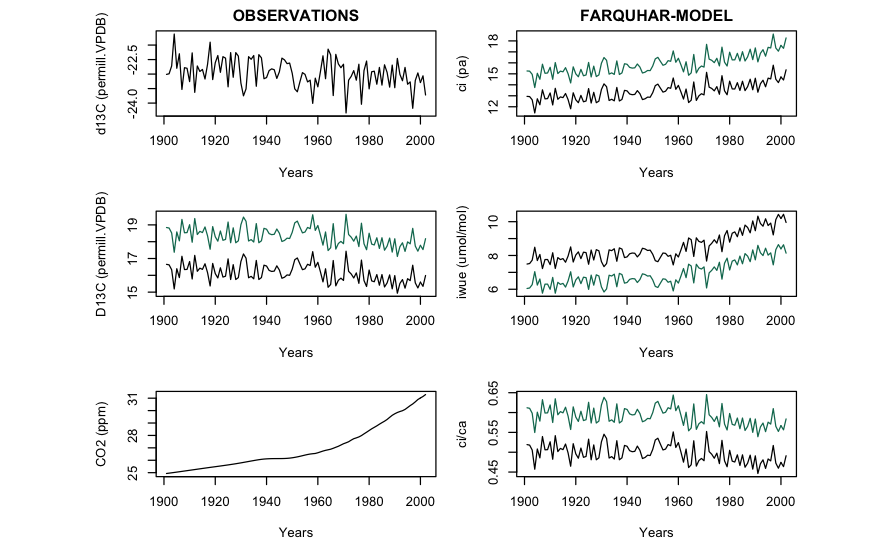

```r
plot(ci/ca,ylab="ci/ca",xlab="Years", main="", ylim=c(range(c(ci/ca, ci.leaf/ca))))
        lines(ci.leaf/ca, col="#0B775E")
```

Question 4: What differences do you observe between physiological indices at stem level and leaf level?

### Including Photorespiration

The version of the Farquhar model used above is a simplified description of the isotopic discrimination. It does not include the fractionation effects during the transfer of CO2 from substomatal cavities to the site of fixation via the mesophyll, and during mitochondrial respiration and photorespiration. While the mesophyll fractionation and their values remain highly unconstrained, recent studies have recommended the inclusion of the photorespiratory effect in the discrimination model as this term contributes to an increase of Δ13C with ca rise by 0.004‰ ppm-1 (Keeling et al., 2017; Lavergne et al., 2019).

A Farquhar model that includes the photorespiratory term is as follows:

Δ13C = a+(b-a)*(ci/ca) -f*(Gst/ca)

The photorespiratory term is the: f*(Gst/ca)

The fractionation due to photorespiration, f, is 12 permil.

Gst (or Γ*, Gamma Star) is the CO2 compensation point in the absence of mitochondrial respiration (Pa), it is calculated from the temperature (T) and atmospheric pressure response.You can use the gammastar(tc, patm_lil) function from the rpmodel to calculate Gamma Star.

The temperature temporal window that will be used will be (July-August):

```r
gridded.tt.data <- ts(read.table("CRU_TT.txt",header=T),start=1901,frequency=1)
tt.JA <- rowMeans(gridded.tt.data[,c(7,8)])
tt.JA <- ts(tt.JA ,start=1901,frequency =1)
```

Calculate gamma star `Gst` as follows:

```r
tc <- tt.JA # and patm_lil has been defined earlier.
Gst <- gammastar(tc, patm_lil)
```

And the photorespiratory term `photoresp_term` as follows:

```r
f=12 #The fractionation due to photorespiration
photoresp_term <- f*(Gst/ca) # ca is  in Pa
```

Calculate ci to include photorespiration:

```r
ci.leaf.photo <-  ca*(d13C.disc.leaf-a+photoresp_term)/(b-a)
```

And iwue to include photorespiration:

```r
iwue.leaf.photo <- (ca-ci.leaf.photo)/1.6
```

Plot the leaf level physiological parameters using the simple and photorespiration models:

```r
layout(matrix(1:6,nrow = 3, ncol = 2,byrow = F), widths = c(4,4),heights = c(2,2,2),respect = TRUE)
par(mar=c(4,5,2,0.1))
# Note you might need to adjust the ylim values.
plot(TR13,ylab="d13C (permil.VPDB)",xlab="Years", main="OBSERVATIONS")
plot(d13C.disc.leaf,ylab="D13C (permil.VPDB)",xlab="Years", main="")
```

```r
plot(ca,ylab="CO2 (pa)",xlab="Years", main="")
plot(ci.leaf,ylab="ci (pa)",xlab="Years", main="FARQUHAR_MODEL",ylim=c(range(c(ci.leaf, ci.leaf.photo))))
```

```r
        lines(ci.leaf.photo, col="#0B775E")
plot(iwue.leaf,ylab=" iwue (umol/mol)",xlab="Years", main="",ylim=c(range(c(iwue.leaf, iwue.leaf.photo))))
```

```r
        lines(iwue.leaf.photo, col="#0B775E")
plot(ci.leaf/ca,ylab="ci/ca",xlab="Years", main="",ylim=c(range(c(ci/ca, ci.leaf.photo/ca))))
```

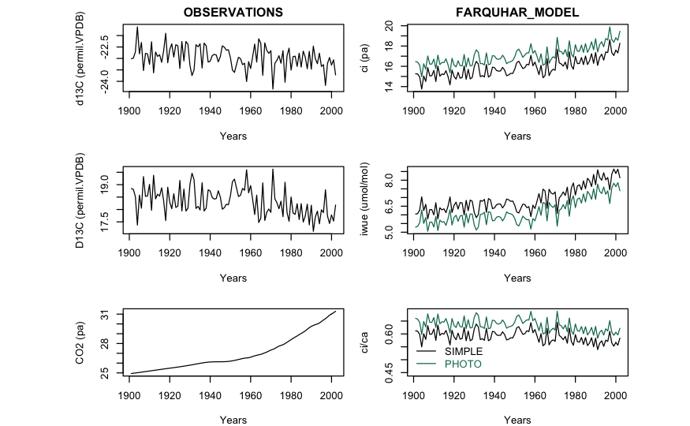

```r
        lines(ci.leaf.photo/ca, col="#0B775E")

legend("bottomleft",c("SIMPLE", "PHOTO"),lwd= c(1,1), bty = "n", col=c("black","#0B775E"),
       text.col=c("black","#0B775E"),ncol=1)
```

Question 5: Do the trends and amplitude of interannual variability vary between the simple model and the one including photorespiration?

## PART 4: Interpreting iWUE and leaf gas exchange strategies

### Temporal trends

From the parts above, you have now calculated physiological parameters using best practices to account for most fractionation factors, using the most updated source data, and scaling d13C measurements to leaf level.

In the following, you will interpret variations of these physiological parameters. You will focus on those physiological parameters using the model with photorespiration.

First, compute the trends of iWUE, ci and ci/ca over the period of record. You can use the `lm` and the `summary` functions to look at- and report the statistics (R2, p value). Here is a first example with iWUE:

```r
iwue.linear <- lm(iwue.leaf.photo ~ seq(1901,2002,by=1))
summary(iwue.linear)
```

```
Call:
lm(formula = iwue.leaf.photo ~ seq(1901, 2002, by = 1))

Residuals:
     Min       1Q   Median       3Q      Max
-1.21685 -0.30223  0.06374  0.28622  1.02815

Coefficients:
                          Estimate Std. Error t value Pr(>|t|)
(Intercept)             -31.904540   2.785285  -11.46   <2e-16 ***
seq(1901, 2002, by = 1)   0.019517   0.001427   13.68   <2e-16 ***
---
Signif. codes:  0 ‘***’ 0.001 ‘**’ 0.01 ‘*’ 0.05 ‘.’ 0.1 ‘ ’ 1

Residual standard error: 0.4244 on 100 degrees of freedom
Multiple R-squared:  0.6516,    Adjusted R-squared:  0.6481
F-statistic:   187 on 1 and 100 DF,  p-value: < 2.2e-16
```

Repeat these steps for ci and ci/ca (you can copy lines 274 and 275 and replace iwue by ci and ci/ca):

```r
ci.linear <- lm(ci.leaf.photo ~ seq(1901,2002,by=1))
summary(ci.linear)
```

```
Call:
lm(formula = ci.leaf.photo ~ seq(1901, 2002, by = 1))

Residuals:
     Min       1Q   Median       3Q      Max
-1.28625 -0.43698 -0.02535  0.39993  1.70161

Coefficients:
                          Estimate Std. Error t value Pr(>|t|)
(Intercept)             -30.207060   3.800873  -7.947 2.95e-12 ***
seq(1901, 2002, by = 1)   0.024234   0.001947  12.444  < 2e-16 ***
---
Signif. codes:  0 ‘***’ 0.001 ‘**’ 0.01 ‘*’ 0.05 ‘.’ 0.1 ‘ ’ 1

Residual standard error: 0.5791 on 100 degrees of freedom
Multiple R-squared:  0.6076,    Adjusted R-squared:  0.6037
F-statistic: 154.9 on 1 and 100 DF,  p-value: < 2.2e-16
```

```r
ci.ca.linear <- lm(ci.leaf.photo/ca ~ seq(1901,2002,by=1))
summary(ci.ca.linear)
```

```
Call:
lm(formula = ci.leaf.photo/ca ~ seq(1901, 2002, by = 1))

Residuals:
      Min        1Q    Median        3Q       Max
-0.054390 -0.015891 -0.003115  0.013084  0.061275

Coefficients:
                          Estimate Std. Error t value Pr(>|t|)
(Intercept)              1.389e+00  1.384e-01  10.033  < 2e-16 ***
seq(1901, 2002, by = 1) -3.866e-04  7.092e-05  -5.452  3.6e-07 ***
---
Signif. codes:  0 ‘***’ 0.001 ‘**’ 0.01 ‘*’ 0.05 ‘.’ 0.1 ‘ ’ 1

Residual standard error: 0.02109 on 100 degrees of freedom
Multiple R-squared:  0.2291,    Adjusted R-squared:  0.2214
F-statistic: 29.72 on 1 and 100 DF,  p-value: 3.604e-07
```

Plot time-series of iWUE, ci and ci/ca and add the linear trend. Here is a first example with iWUE linear trend. You need to add the linear trend for ci and ci/ca:

```r
layout(matrix(1:3,nrow = 1, ncol = 3,byrow = T), widths = c(3,3,3),heights = c(3,3,3),respect = TRUE)
ts.plot(iwue.leaf.photo,ylab=" iwue (umol/mol)",xlab="Years", main="")
abline(iwue.linear, col="#0B775E",lwd=2,lty=3)
```

```r
ts.plot(ci.leaf.photo,ylab=" ci(pa)",xlab="Years", main="")
abline(ci.linear, col="#0B775E",lwd=2,lty=3)
```

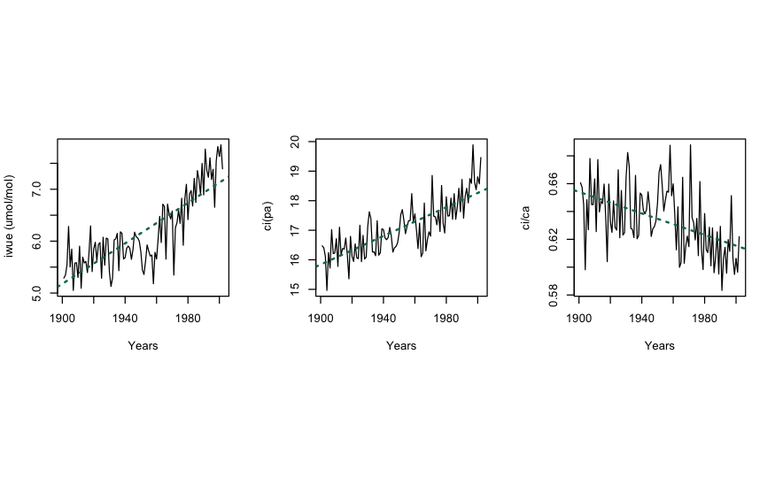

```r
# add linear trend

ts.plot(ci.leaf.photo/ca,ylab="ci/ca",xlab="Years", main="")
abline(ci.ca.linear, col="#0B775E",lwd=2,lty=3)
```

```r
# add linear trend
```

Question 6: Using computed statistics above, Describe the trends and their significance for each of the physiological indices.

Question 7: How do you interpret the ci/ca trends in term of stomatal conductance?

Question 8: Was the iWUE,ci ot ci/ca increase steady over time?

To answer the following questions, you need to convert the ci from pa to ppm

```r
ci.leaf.photo.ppm <- ci.leaf.photo /(( 1.e-6 ) * patm_lil)

#convert to a time series
ci.leaf.photo.ppm <- ts(ci.leaf.photo.ppm, start=1901, frequency = 1)

# rename the column to something nicer
colnames(ci.leaf.photo.ppm) <- "ci.leaf.photo.ppm"
```

You also need to use ca in ppm

```r
ca.ppm <- ATM.CO2
```

Question 9: What was the rate of the ci (ppm.year-1) increase over time?

Question 10: Was this rate steady/constant over time?

Question 11: compared to the rate of ca, was the rate of ci:  
a) proportional to ca?  
b) similar to ca?

To answer this question, you need to estimate the rate of ca using `lm` and `summary` functions.

Estimate the ci increase relative to ca. You can do this by regressing ci by ca.

```r
ci.rate <- lm(ci.leaf.photo.ppm ~ ca.ppm)
summary(ci.rate)
```

```
Call:
lm(formula = ci.leaf.photo.ppm ~ ca.ppm)

Residuals:
     Min       1Q   Median       3Q      Max
-15.3459  -5.1241  -0.1495   3.9830  18.8509

Coefficients:
            Estimate Std. Error t value Pr(>|t|)
(Intercept) 67.04266    9.94327   6.743 1.02e-09 ***
ca.ppm       0.42441    0.03092  13.724  < 2e-16 ***
---
Signif. codes:  0 ‘***’ 0.001 ‘**’ 0.01 ‘*’ 0.05 ‘.’ 0.1 ‘ ’ 1

Residual standard error: 6.475 on 100 degrees of freedom
Multiple R-squared:  0.6532,    Adjusted R-squared:  0.6497
F-statistic: 188.4 on 1 and 100 DF,  p-value: < 2.2e-16
```

Question 12: Report the rate of ci and describe it in terms of a) proportional b) similar. Note that this rate translate the ci increase for each ppm of ca increase.

Note: the rate of ci can be found in the coefficient section of the output of the lm function above.

Question 13: Looking at all physiological indices, their trends and rates, how do you interpret the temporal variations of stomatal conductance and photosynthesis of these trees?

### Leaf gas exchange strategies

With rising ca, variations in plant Δ13C have been grouped into three leaf gas-exchange strategies:

1. constant ci
2. constant ci/ca
3. constant ca − ci

The first two strategies are considered active, and the third passive. These theoretical considerations serve as the basis for the interpretation of the physiological mechanisms underlying iWUE trends. Recently, a dynamic strategy has been described for low CO2 levels (<400 ppm) where trees switch between the 3 strategies described above.

Note, we will use the ca and ci in ppm to facilitate discussion.

#### Calculate ci following scenario 1:

```r
# first, estimate the average ci from tree ring for the first decade of the record
ci.average_1decade <- mean(ci.leaf.photo.ppm[1:10])
ci.scenario1 <- ts(rep(ci.average_1decade, 102), start=1901, frequency=1)
```

#### Calculate ci following scenario 2:

```r
# first, estimate the average ci/ca from tree ring for the first decade of the record
cica.average_1decade <- mean((ci.leaf.photo.ppm/ca.ppm)[1:10])
ci.scenario2 <-ca.ppm*cica.average_1decade
```

#### Calculate ci following scenario 3:

```r
# first, estimate the average ca-ci from tree ring for the first decade of the record
caci.average_1decade <- mean((ca.ppm-ci.leaf.photo.ppm)[1:10])
ci.scenario3 <-ca.ppm-caci.average_1decade
```

Plot the observed ci with the predicted ci following the 3 scenarios:

```r
ts.plot(ci.leaf.photo.ppm,ylab="ci (pa)",xlab="Years", main="", ylim=c(177,300))
lines(ci.scenario1, lty=2, col="#F2AD00",lwd=2)
```

```r
lines(ci.scenario2, lty=5, col="#F2AD00",lwd=3)
lines(ci.scenario3, lty=3, col="#F2AD00",lwd=2)
```

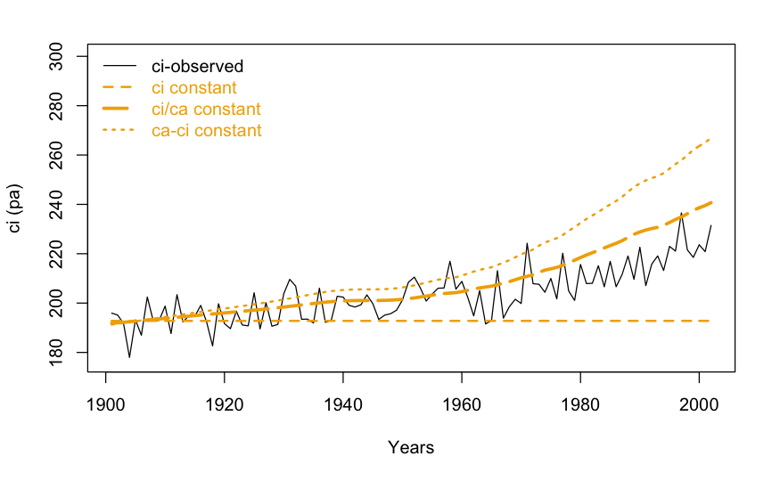

```r
legend("topleft",c("ci-observed", "ci constant","ci/ca constant","ca-ci constant"),
       lty= c(1,2,5,3), lwd=c(1,2,3,2),bty = "n", col=c("black","#F2AD00","#F2AD00","#F2AD00"),
       text.col=c("black","#F2AD00","#F2AD00","#F2AD00"), ncol=1)
```

Question 14: Does the observed ci (derived from tree rings) follow any of the 3 scenarios or a dynamic strategy (switching betwen different strategies)?

Question 15: Does the observed ci follow a scenario consistently throughout the record?

## Discussion

Based on climate trends at the LIL site and tree ring d13C sensitivity to these climate factors/trends, discussed in Notebook1, answer the following:

Question 16: How do you interpret the change (increase) in iwue?

Question 17: is it driven by an increase is photosynthetic assimilation?

Question 18: is it driven by a decrease is stomatal conductance?

Question 19: Are iwue, photosynthetic assimilation, stomatal conductance driven by:

1. rising ca?
2. trends in climate?
3. both?

Question 20: Discuss how trends in ca and/or climate are affecting tree physiology.